# Experiments in Generative Evolution

Simon Hickinbotham

12/01/2021

# Terminology/strategy

- grow a network of “undifferentiated cells” as “undifferentiated nodes” (u-nodes) connected by “undifferenitated edges” (u-edges)

# Setting up

Ideally we’d try to grow from a single foundation, and have a “stimulus point” that triggers conversion from sensing nodes to support nodes. But since determining where to grow - even randomly - is complicated, we’ll start with a uniform grid of cells. This is potentially wasteful but it allows us to get to solving the main issues early.

To check how the logic might work in a real space, let’s set up some assumptions. We’ll store the functions/classes in the following code block as we develop until we’ve got that far.

## Edge numbering

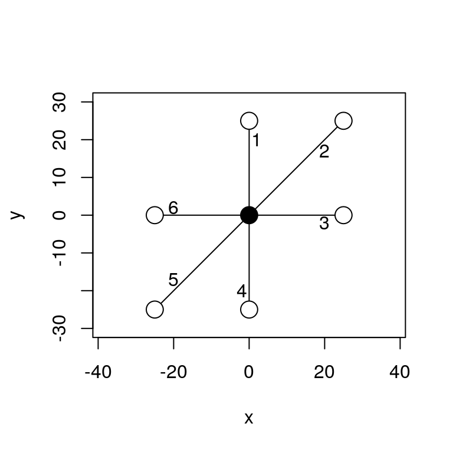

# Pre-building the u-net

## Regular version

Adding nodes on a grid is pretty straghtforward. Here we’ll create a regular square lattice with cross-braces. We commence with the nodes:

```r
addnode <- function(nodes,n=0,xpos=0,ypos=0,level=-1,type="U"){

  newrow <- data.frame(n = n,x = xpos ,y= ypos, level = level, type = type, stringsAsFactors = F)

  if(is.null(nodes))
    nodes <- newrow
  else
    nodes <- rbind(nodes,newrow, stringsAsFactors = F)

  return(nodes)

}
```

Now the edges. Let’s start by using integers only, cos then we can predict the position and we don’t have to minimise any distances to find neighbours.

```r
#' edges <- addedge(edges,nodes,n,dir="W",ostep)
addedge <- function(edges=NULL,nodes,n,dir,dist){

  #Identify the node to connect to:
  n1 <- nodes[nodes$n==n,]

  if(nrow(n1)!=1){
    message(sprintf("ERROR: found %d rows for node %d",nrow(n1),n))
    return(NULL)
  }

  found <- F
  if(dir == "W"){
    n2 = nodes[nodes$x == (n1$x[1]-dist) & nodes$y == n1$y[1],]
    if(nrow(n2)!=1){
      message(sprintf("ERROR: found %d rows for neighbour node",nrow(n1),n))
      return(NULL)
    }
    else{
      found = T
    }
  }
  if(dir == "S"){
    n2 = nodes[nodes$x == (n1$x[1]) & nodes$y == (n1$y[1]-dist),]
    if(nrow(n2)!=1){
      message(sprintf("ERROR: found %d rows for neighbour node",nrow(n1),n))
      return(NULL)
    }
    else{
      found = T
    }
  }
  if(dir == "SW"){
    n2 = nodes[nodes$x == (n1$x[1]-dist) & nodes$y == (n1$y[1]-dist),]
    if(nrow(n2)!=1){
      message(sprintf("ERROR: found %d rows for neighbour node",nrow(n1),n))
      return(NULL)
    }
    else{
      found = T
    }
  }

  newrow <- data.frame(from = n1$n[1], to = n2$n[1], type = "U")


  if(is.null(edges))
    edges <- newrow
  else
    edges <- rbind(edges,newrow, stringsAsFactors = F)

  return(edges)
}
```

```r
# constants
iel = 50            # ideal edge length
xlim = c(-100,100)  # x range
ylim = c(0,200)     # y range
ostep = 20

# generate the nodes:
nodes <- NULL
edges <- NULL
n = 1
e = 1
for(yy in seq(ylim[1],ylim[2],ostep)){
  for(xx in seq(xlim[1],xlim[2],ostep)){
      nodes <- addnode(nodes,n=n,xpos=xx,ypos=yy)

      #horizontal edges:
      if(xx>xlim[1])
        edges <- addedge(edges,nodes,n,dir="W",ostep)
      #vertical edges:
      if(yy>ylim[1])
        edges <- addedge(edges,nodes,n,dir="S",ostep)
      #vertical edges:
      if(xx>xlim[1] & yy>ylim[1])
        edges <- addedge(edges,nodes,n,dir="SW",ostep)


      #increment the node number
      n = n+1
  }
}

# Set the foundation nodes:
nodes$type[nodes$n>=5 & nodes$n <=7]<-"F"
net <- list()
net$n <- nodes
net$e <- edges

stim <- data.frame(x=-5,y=145)

innet <- net
```

## irregular version

An alternative to the above would be to generate a set of random nodes in the space and then connect the edges via e.g. a Delaunay triangulation. Hard to say what the advantage of this would be

# Growing the network levels

Let’s have a function to plot the network - we’ll animate this later:

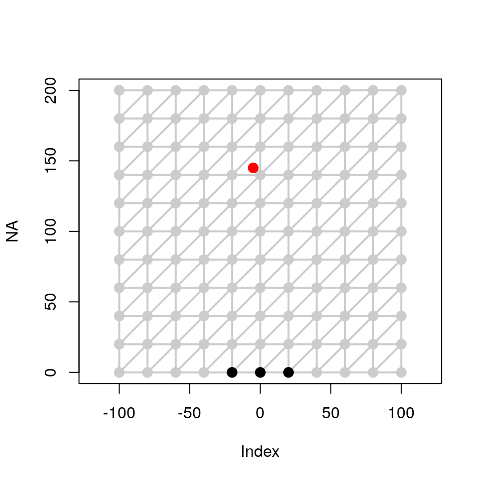

```r
plotnet <- function(net,stim,xlim=c(-100,100),ylim=c(0,500),pcols=NULL){
  nodes <- net$n
  edges <- net$e
  plot(NA,xlim=xlim,ylim=ylim,asp=T)

  #Draw the edges
  for(ee in 1:nrow(edges)){
    n0 <- nodes[nodes$n == edges$from[ee],]
    n1 <- nodes[nodes$n == edges$to[ee],]
    segments(x0=n0$x,x1=n1$x,y0=n0$y,y1=n1$y,lwd = 2,col="grey80")
  }

  #Draw the nodes
  un <- nodes[nodes$type=="U",]
  points(x=un$x,y=un$y,pch=20,cex=2,col="grey80")
  fn <- nodes[nodes$type=="F",]
  points(x=fn$x,y=fn$y,pch=20,cex=2,col="black")

  points(x=stim$x,y=stim$y,pch=20,cex=2,col="red")

  if(is.null(pcols))
    pcols = rainbow(max(nodes$level))

  #Draw the propagation now:
  for(pp in 1:max(nodes$level)){
    pn <- nodes[nodes$level==pp & nodes$type!="F",]
    if(nrow(pn)>0)
      points(x=pn$x,y=pn$y,pch=20,col=pcols[pp])
  }
}

plotnet(net,stim,xlim,ylim)
```

OK that’s a good start - we need to propagate the connectivity between the foundation and the stimulus

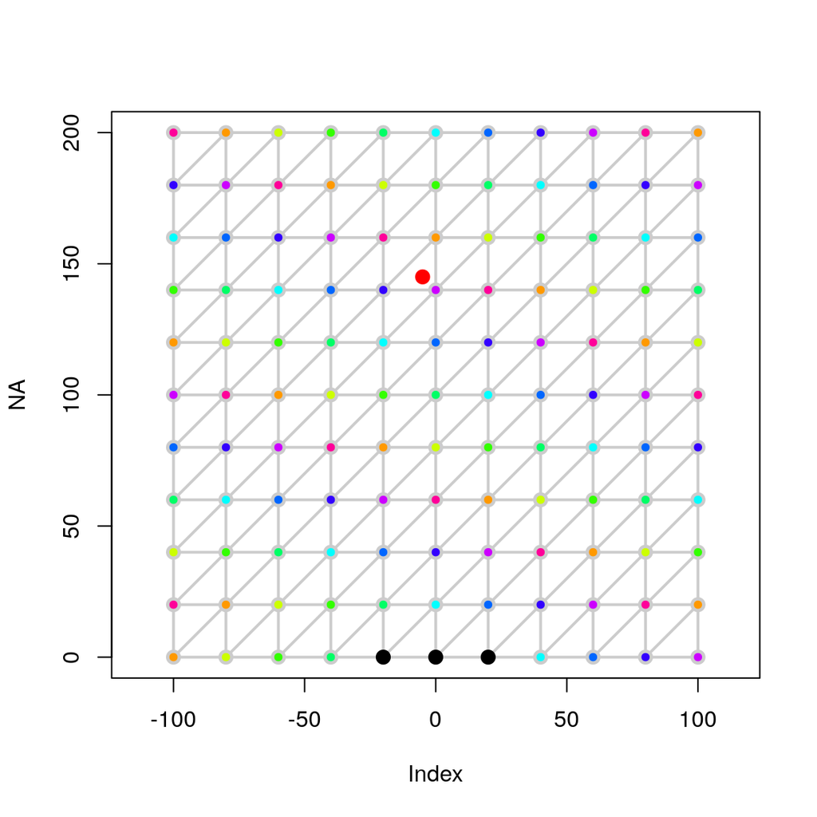

```r
propagate <- function(net){
  if(max(net$n$level)==-1){
    sn <- net$n[net$n$type=="F",]
    sl <- 1

    pe <- edges[edges$from %in% sn$n | edges$to %in% sn$n,]
    newn <- unique(c(pe$from,pe$to))
    newn <- newn[!(newn %in% sn$n)]

    net$n$level[net$n$n %in% newn] <- sl
  }
  else{
    sn <- net$n[net$n$level==max(net$n$level),]
    sl <- max(sn$level)+1
    #message(sprintf("adding level %d ",sl))

    pe <- edges[edges$from %in% sn$n | edges$to %in% sn$n,]
    newn <- unique(c(pe$from,pe$to))
    newn <- newn[!(newn %in% sn$n)]

    net$n$level[net$n$n %in% newn & net$n$level == -1] <- sl
  }

  return(net)
}

net <- innet
nsteps <- 15
pcols  <- rainbow(n=10)
plotnet(net,stim,xlim,ylim,pcols)
```

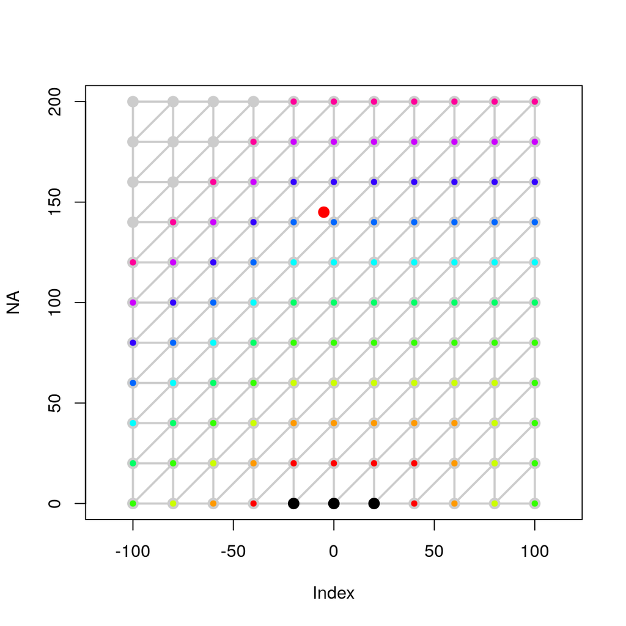

```r
oldnet <- net

for(ll in 1:nsteps){
  net <- propagate(net)
  plotnet(net,stim,xlim,ylim,pcols)
}
```

# Growing the network from scratch

I did a little work on actually growing the network, rather than establishing a grid that covers the whole space.

Here’s the initial network: a foundation of two connected nodes

```r
# constants
iel = 50

nodes <- data.frame(n = c(0,1),x = c(-25,25),y=c(0,0),level=c(0,0),type=c("F","F"),e1=c(F,F),e2=c(F,F),e3=c(T,F),e4=c(F,F),e5=c(F,F),e6=c(F,T))
edges <- data.frame(from = 0, to = 1, type = "F")
net <- list()
net$n <- nodes
net$e <- edges
```